# Gene Networks 2

Julin Maloof  
May 30, 2019

### Clustering vs Networks

- In the last lab you learned how to group genes into *clusters* based on similar expression patterns.
- In this lab we extend this concept to build *gene networks*
- Gene networks are graphs that show connections between genes with similar expression.

### Correlation Network

- The goal is to connect genes with the most similar expression
- One simple way to do this is to use correlation as a measure of expression similarity
- *Why* might we want to do this?

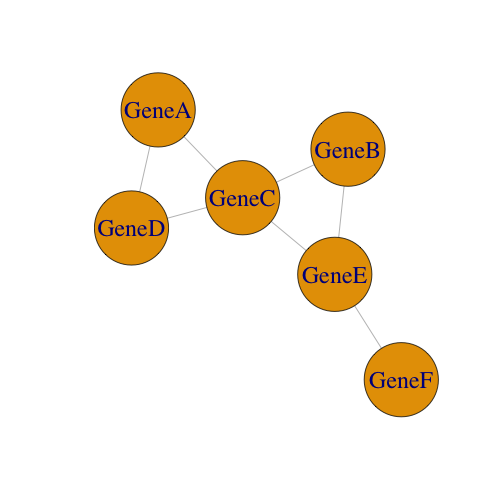

### Correlation Matrix

First calculate the correlation between each gene's expression across samples

|  | GeneA | GeneB | GeneC | GeneD | GeneE | GeneF |
| --- | --- | --- | --- | --- | --- | --- |
| GeneA | 1.00 | 0.12 | 0.75 | 0.86 | 0.49 | 0.32 |
| GeneB | 0.12 | 1.00 | 0.92 | 0.08 | 0.88 | 0.08 |
| GeneC | 0.75 | 0.92 | 1.00 | 0.81 | 0.78 | 0.02 |
| GeneD | 0.86 | 0.08 | 0.81 | 1.00 | 0.28 | 0.59 |
| GeneE | 0.49 | 0.88 | 0.78 | 0.28 | 1.00 | 0.78 |
| GeneF | 0.32 | 0.08 | 0.02 | 0.59 | 0.78 | 1.00 |

### Adjacency Matrix

Then create an adjacency matrix with “1” indicating genes that are correlated above a threshold, and “0” indicating below threshold.

Connect genes with a “1”

|  | GeneA | GeneB | GeneC | GeneD | GeneE | GeneF |
| --- | --- | --- | --- | --- | --- | --- |
| GeneA | 0 | 0 | 1 | 1 | 0 | 0 |
| GeneB | 0 | 0 | 1 | 0 | 1 | 0 |
| GeneC | 1 | 1 | 0 | 1 | 1 | 0 |
| GeneD | 1 | 0 | 1 | 0 | 0 | 0 |
| GeneE | 0 | 1 | 1 | 0 | 0 | 1 |
| GeneF | 0 | 0 | 0 | 0 | 1 | 0 |

### Terminology

- Genes are *nodes*
- Connections between genes are *edges*

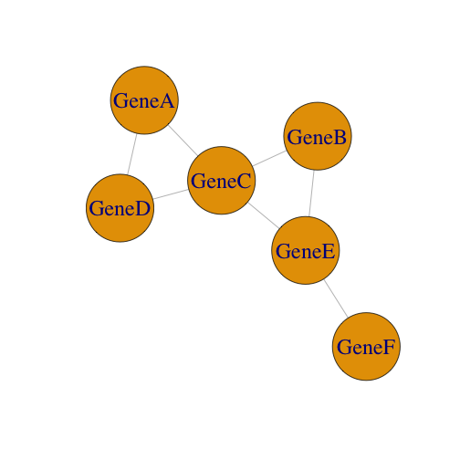

### Mutual Rank Networks

One problem with correlation networks is that it is hard to know what threshold to pick. Further, correlation values can be affected by “noise” in the experiment, that may not be relevant.

An alternative (and in my hands better) approach is to use **Mutual Ranks**. We can connect genes with the the highest correlations, regardless of their precise value.

[More info](https://www.ncbi.nlm.nih.gov/pmc/articles/PMC2762411/)

Here, we:

1. Create a pairwise correlation matrix, as above
2. Rank the correlations from strongest to weakest
3. Compute the pairwise geometric mean ranks
4. Choose a rank-based cutoff to create the adjacency matrix

### Correlation Matrix

First calculate the correlation between each gene's expression across samples

|  | GeneA | GeneB | GeneC | GeneD | GeneE | GeneF |
| --- | --- | --- | --- | --- | --- | --- |
| GeneA | 1.00 | 0.12 | 0.75 | 0.86 | 0.49 | 0.32 |
| GeneB | 0.12 | 1.00 | 0.92 | 0.08 | 0.88 | 0.08 |
| GeneC | 0.75 | 0.92 | 1.00 | 0.81 | 0.78 | 0.02 |
| GeneD | 0.86 | 0.08 | 0.81 | 1.00 | 0.28 | 0.59 |
| GeneE | 0.49 | 0.88 | 0.78 | 0.28 | 1.00 | 0.78 |
| GeneF | 0.32 | 0.08 | 0.02 | 0.59 | 0.78 | 1.00 |

### Rank Matrix

|  | GeneA | GeneB | GeneC | GeneD | GeneE | GeneF |
| --- | --- | --- | --- | --- | --- | --- |
| GeneA | NA | 3 | 4 | 1 | 4 | 3 |
| GeneB | 5 | NA | 1 | 5 | 1 | 4 |
| GeneC | 2 | 1 | NA | 2 | 2 | 5 |
| GeneD | 1 | 4 | 2 | NA | 5 | 2 |
| GeneE | 3 | 2 | 3 | 4 | NA | 1 |
| GeneF | 4 | 4 | 5 | 3 | 2 | NA |

### Average Ranks

|  | GeneA | GeneB | GeneC | GeneD | GeneE | GeneF |
| --- | --- | --- | --- | --- | --- | --- |
| GeneA | NA | 3.87 | 2.83 | 1.00 | 3.46 | 3.46 |
| GeneB | 3.87 | NA | 1.00 | 4.74 | 1.41 | 4.24 |
| GeneC | 2.83 | 1.00 | NA | 2.00 | 2.74 | 5.00 |
| GeneD | 1.00 | 4.74 | 2.00 | NA | 4.47 | 2.45 |
| GeneE | 3.46 | 1.41 | 2.74 | 4.47 | NA | 1.58 |
| GeneF | 3.46 | 4.24 | 5.00 | 2.45 | 1.58 | NA |

### Adjacency Matrix

Mutual Rank <= 3

|  | GeneA | GeneB | GeneC | GeneD | GeneE | GeneF |
| --- | --- | --- | --- | --- | --- | --- |
| GeneA | 0 | 0 | 1 | 1 | 0 | 0 |
| GeneB | 0 | 0 | 1 | 0 | 1 | 0 |
| GeneC | 1 | 1 | 0 | 1 | 1 | 0 |
| GeneD | 1 | 0 | 1 | 0 | 0 | 1 |
| GeneE | 0 | 1 | 1 | 0 | 0 | 1 |
| GeneF | 0 | 0 | 0 | 1 | 1 | 0 |

### Network

|  | GeneA | GeneB | GeneC | GeneD | GeneE | GeneF |
| --- | --- | --- | --- | --- | --- | --- |
| GeneA | 0 | 0 | 1 | 1 | 0 | 0 |
| GeneB | 0 | 0 | 1 | 0 | 1 | 0 |
| GeneC | 1 | 1 | 0 | 1 | 1 | 0 |
| GeneD | 1 | 0 | 1 | 0 | 0 | 1 |
| GeneE | 0 | 1 | 1 | 0 | 0 | 1 |
| GeneF | 0 | 0 | 0 | 1 | 1 | 0 |

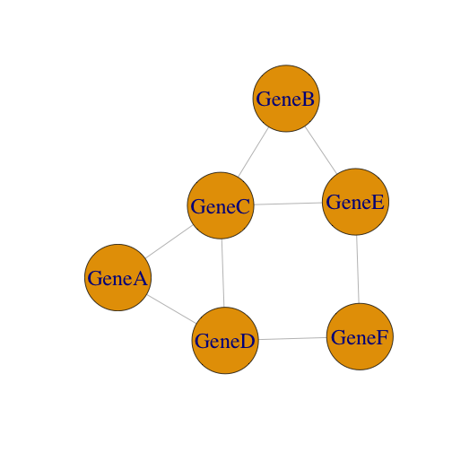

### Limitations

Correlation networks easy to make and easy to understand but have some limitations

### Limitations

Correlation networks easy to make and easy to understand but have some limitations

- Is a hard threshold proper?
- What is the right threshold?
- Are correlations even the right measure?
- Directionality?

### Additional method:

- Weighted Gene Correlation Networks. Uses a “soft” threshold. [(WGCNA)](https://labs.genetics.ucla.edu/horvath/htdocs/CoexpressionNetwork/Rpackages/WGCNA/) (nice tutorials also YouTube videos)